# Assignment 1

Benjamín Chumaceiro | Rosalía Contreras | Eduardo Cort Pons | Maria Joyce | Ignacio Mouawad | Srishti Singh

10/1/2019

## SOCIAL NETWORKS ANALYSIS

#### Profesor: ALVARO ROMERO MIRALLES

#### Program: MBD April intake

#### Group Assignment 1

#### Team A

On this first assignment, applying the basic functions of the Igraph package is required. The following datasets are going to be used:

- Actors dataset - undirected graph - : For the 2005 Graph Drawing conference a data set was provided of the IMDB movie database. We will use a reduced version of this dataset, which derived all actor-actor collaboration edges where the actors co-starred in at least 2 movies together between 1995 and 2004.
- Wikipedia Dataset - directed graph - . The vertices of this network are wikipedia pages. The label of each vertex is the title of the wikipedia page. Edges represent hyperlinks between wikipedia pages; that is, if there is an edge from page A to page B, it means that page A has an hyperlink to page B. The dataset is available at: https://www.cs.upc.edu/~CSN/lab/wikipedia.gml

You have to complete the code chunks in this document but also analyze the results, extract insights and describe them in an understandable way.

Please, write all your conclusions in blue.

# Loading data

In this section, the goal is loading the datasets given, building the graph and analyzing basics metrics. Include the edge or node attributes you consider.

```r
library(igraph)
library(data.table)
library(stringr)
# Building the graph

#actors edges graph
actors<-fread("imdb_actor_edges.tsv")


#actors key graphs
actorskey<-fread("imdb_actors_key.tsv")

#joining actors into 1
actedge<-as.data.frame(actors, directed = F)
actkey<-as.data.frame(actorskey, directed = F)
actors_graph<- graph.data.frame(d=actedge, vertices = actkey, directed = F)

#wikipedia graph
wikipedia <- fread("wikipedia.gml.txt", fill = TRUE)

wikigraph<- read_graph( "https://www.cs.upc.edu/~CSN/lab/wikipedia.gml",format = c("gml"))
```

Describe the values provided by summary function on the graph object.

```r
print("actors summary:")
```

```
## [1] "actors summary:"
```

```r
summary(actors_graph)
```

```
## IGRAPH 79e457e UNW- 17577 287074 --
## + attr: name (v/c), movies_95_04 (v/n), main_genre (v/c), genres
## | (v/c), weight (e/n)
```

```r
print("wikipedia summary:")
```

```
## [1] "wikipedia summary:"
```

```r
summary(wikigraph)
```

```
## IGRAPH 4e9f2a4 D--- 27475 85729 --
## + attr: id (v/n), wikiid (v/n), label (v/c)
```

After loading both datasets and creating the graphs, and using the summary function, we got an UNW- description for Actors. Therefore we can deduce that this graph is (U) Undirected, (N) Named and (W) Weighted. There are 17577 nodes in the network along with 287074 edges. As for the second line,and after merging the 2 actor datasets, the summary function shows the attributes and seperates them by a comma. We have name, main genre, and genres with (v/c) implying vertex attributes with a character types, movies_95_04 as a (v/n) a vertex attribute with numeric type, and weight with (e/n) implying its an edge attribute with a numeric type.

As for the Wikipedia page, we got an D— igraph suggesting that it is (D) Directed. It has 27475 nodes with 85729 edges. It has a wikiid and id (v/n) vertex level attributes with numeric type, and a label (v/c) vertex level attribute of a character attribute.

# Degree distribution

Represent the degree distribution of both networks. For directed graphs, compute the total degree distribution considered the graph as undirected, the in-degree distribution and the out-degree distribution. *How do these distributions look like? Are they similar? What about their means? And their standard deviations with respect to the mean?*

### Wikipedia Graph as Undirected total degree distribution

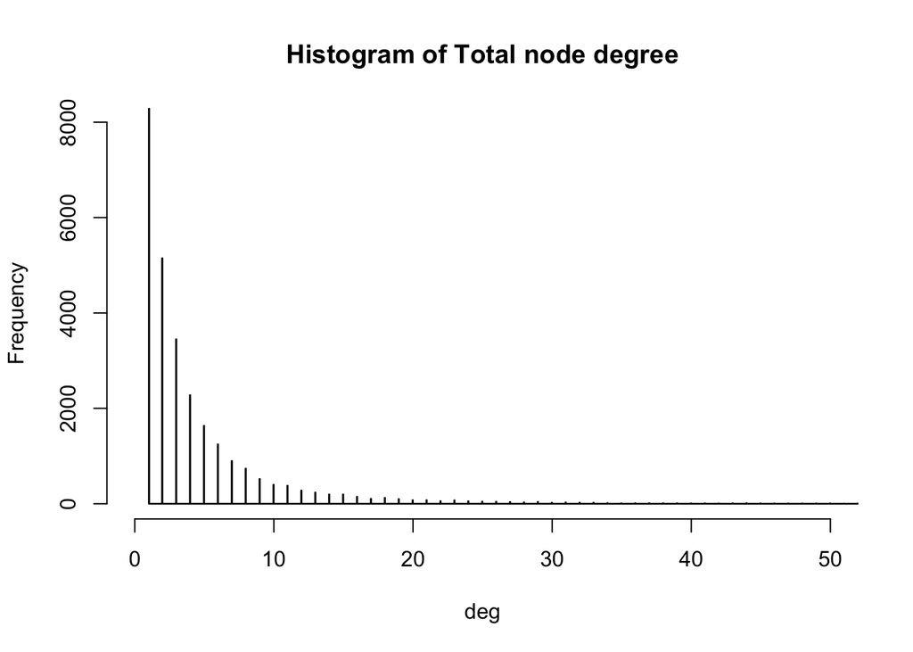

```r
deg <- degree(as.undirected(wikigraph), mode="total")
hist(deg, main="Histogram of Total node degree",xlim=c(0,50), ylim=c(0,8000),breaks = 10000)
```

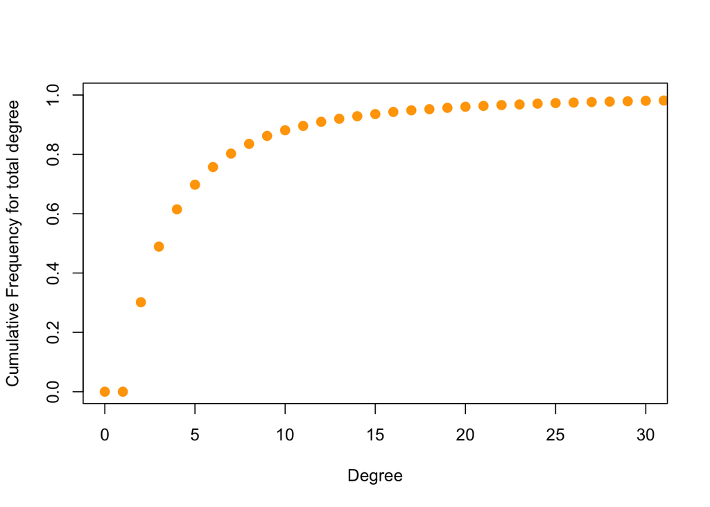

```r
deg.dist <- degree_distribution(as.undirected(wikigraph, mode = "collapse"), cumulative=T, mode="total")
plot( x=0:max(deg), y=1-deg.dist, pch=19, cex=1.2, col="orange",

      xlab="Degree", ylab="Cumulative Frequency for total degree", xlim = c(0,30))
```

```r
print("Mean total: ")
```

```
## [1] "Mean total: "
```

```r
mean(deg)
```

```
## [1] 5.397489
```

```r
print("Standard Deviation:")
```

```
## [1] "Standard Deviation:"
```

```r
sd(deg)
```

```
## [1] 13.06602
```

In the “histogram of node degree” the frequency shows that the most common nodes have degrees around 1 ot 10. When taking the zoom out and looking at outliers, the graph is most highly right-skewed and exhibiting a long tail distribution, meaning that the large majority of nodes have low degrees but a small number of nodes, known as “hubs”, have high degrees. These outliers are the reason why the mean is 5.397489 and and not a number from 1 to 3 where the big concentration of degrees appear graphically.

After examining the cumulative degree distribution, that shows us the total running of frequencies accumulated, we can observe that after 15 degrees the curve stops increasing and becomes constant, therefore the majority of nodes have from 1 to 10 degrees.

The standard deviation is 13.06602 which is a number more than two times the mean, thus the mean is not an exact representation of all the nodes because of the noise.

### Directed Wikipedia Graph in-degree distribution

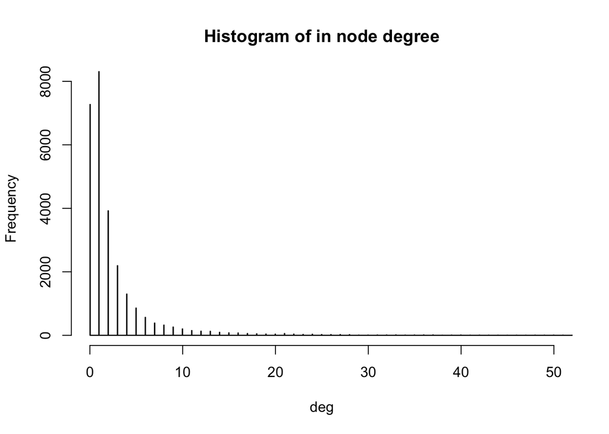

```r
deg <- degree(wikigraph, mode="in" )
hist(deg, main="Histogram of in node degree", xlim=c(0,50), ylim=c(0,8000),breaks = 10000)
```

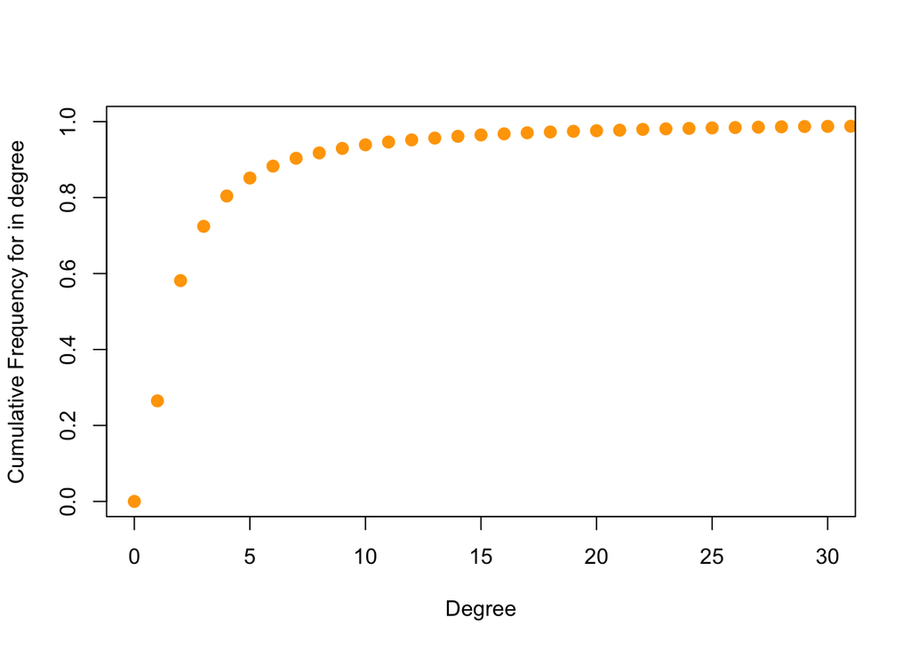

```r
deg.dist <- degree_distribution(wikigraph, cumulative=T, mode="in")
plot( x=0:max(deg), y=1-deg.dist, pch=19, cex=1.2, col="orange",

      xlab="Degree", ylab="Cumulative Frequency for in degree", xlim = c(0,30))
```

```r
print("Mean in degree: ")
```

```
## [1] "Mean in degree: "
```

```r
mean(deg)
```

```
## [1] 3.120255
```

```r
print("Standard Deviation in degree:")
```

```
## [1] "Standard Deviation in degree:"
```

```r
sd(deg)
```

```
## [1] 9.000066
```

After examining the cumulative degree distribution, that shows us the total running of frequencies accumulated, we can observe that after 15 degrees the curve stops increasing and becomes constant, therefore the majority of nodes have from 1 to 10 degrees.

### Directed Wikipedia Graph out-degree distribution

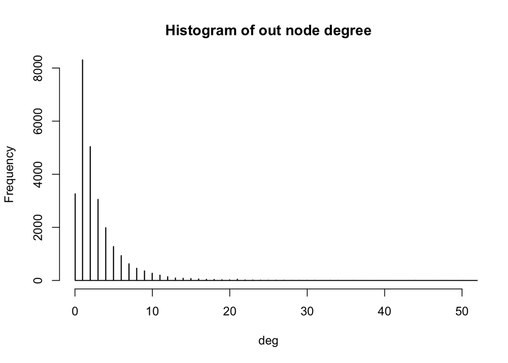

```r
deg <- degree(wikigraph, mode="out")
hist(deg, main="Histogram of out node degree", xlim=c(0,50), ylim=c(0,8000),breaks = 10000)
```

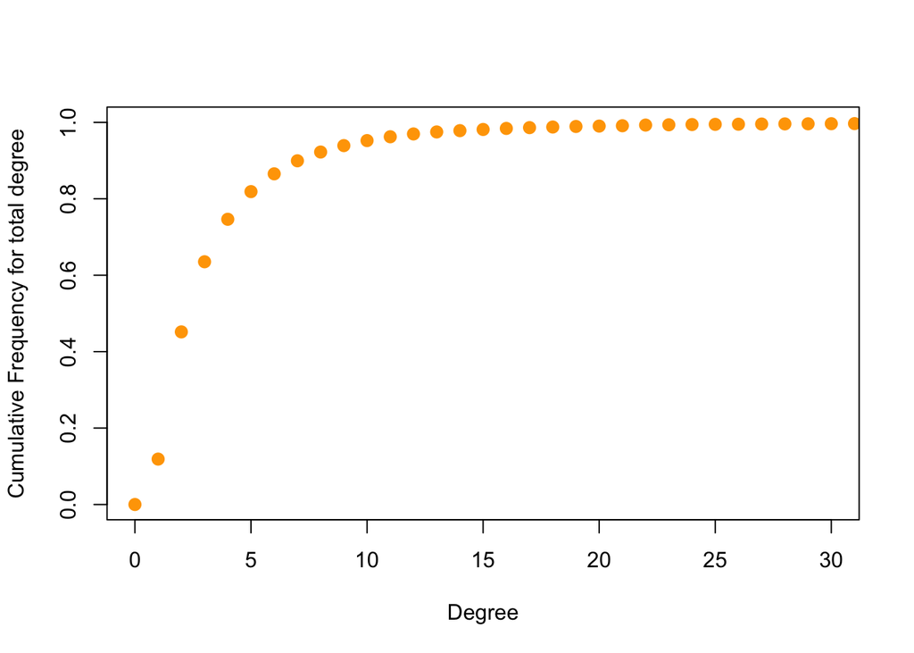

```r
deg.dist <- degree_distribution(wikigraph, cumulative=T, mode="out")
plot( x=0:max(deg), y=1-deg.dist, pch=19, cex=1.2, col="orange",

      xlab="Degree", ylab="Cumulative Frequency for total degree", xlim = c(0,30))
```

```r
print("Mean out degree: ")
```

```
## [1] "Mean out degree: "
```

```r
mean(deg)
```

```
## [1] 3.120255
```

```r
print("Standard Deviation out degree:")
```

```
## [1] "Standard Deviation out degree:"
```

```r
sd(deg)
```

```
## [1] 9.038384
```

After examining the cumulative degree distribution, that shows us the total running of frequencies accumulated, we can observe that after 15 degrees the curve stops increasing and becomes constant, therefore the majority of nodes have from 1 to 10 degrees.

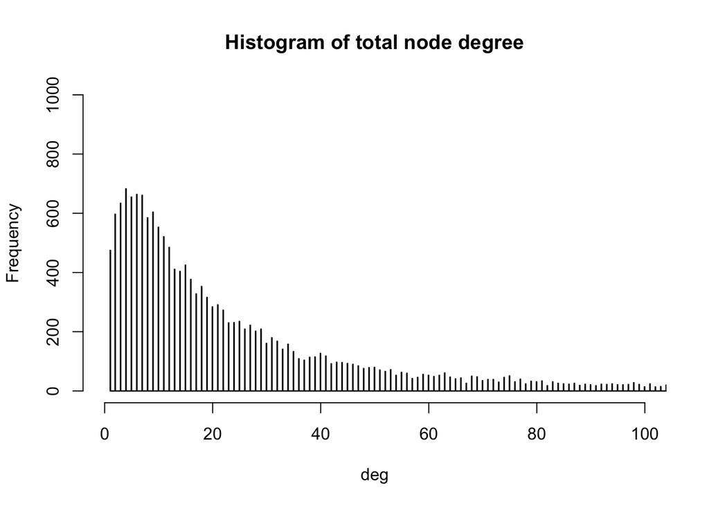

```r
deg <- degree(actors_graph, mode="total")
hist(deg, main="Histogram of total node degree", xlim=c(0,100), ylim=c(0,1000),breaks = 10000)
```

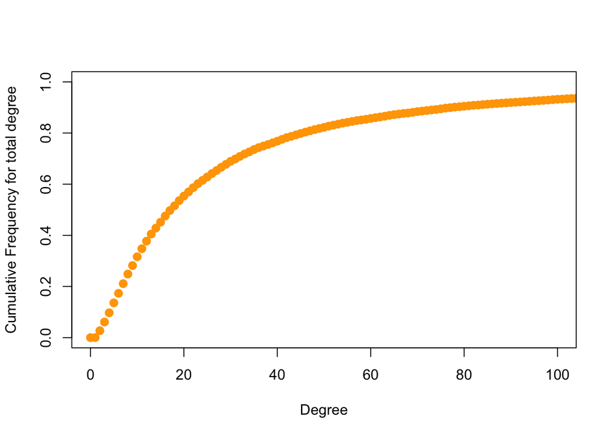

```r
deg.dist <- degree_distribution(actors_graph, cumulative=T, mode="total")
plot( x=0:max(deg), y=1-deg.dist, pch=19, cex=1.2, col="orange",

      xlab="Degree", ylab="Cumulative Frequency for total degree", xlim = c(0,100))
```

```r
print("Mean total: ")
```

```
## [1] "Mean total: "
```

```r
mean(deg)
```

```
## [1] 32.66473
```

```r
print("Standard Deviation:")
```

```
## [1] "Standard Deviation:"
```

```r
sd(deg)
```

```
## [1] 47.63042
```

As for the actors undirected graph, the “histogram of node degree” shows that most nodes have degrees around 1 ot 60. When taking the zoom out and we look at outliers, the graph is most highly right-skewed, meaning that a large majority of nodes have low degree but a small number, known as “hubs”, have high degree. These outliers are the reason why the mean is 32.66473 and not a number arround 1 to 20 where the big concentration of degrees appear graphically.

#### Conclusion

The mean of the actor’s social network (32.66473) is larger than that of the the Wikipedia network (5.397489). This implies that on average each node in the actors network has more connections to other nodes. This makes sense since Wikipedia pages are more unlikely to be connected than actors in a movie.

The standard deviation is larger in the actors network (47.63042) than in the Wikipedia network (13.06602). Therefore, the actors network is affected by actors that have a lot of connections (edges) or a high degree. This phenomenon is also the reason why the mean of the actors network is larger than its median.

# Network Diameter and Average Path Length

Compare the network diameter and the average path length of both networks. Consider the actors graph as unweighted. *Does the Wikipedia graph have a larger diameter than the actors graph? Why? What about the average path length?*

#### Network Diameter

```r
print("wikipedia diameter")
```

```
## [1] "wikipedia diameter"
```

```r
diameter(wikigraph, directed=T)
```

```
## [1] 41
```

```r
print("actors graph diameter")
```

```
## [1] "actors graph diameter"
```

```r
diameter(actors_graph, directed=F, weights=NA)
```

```
## [1] 16
```

We can define the diameter of a network as the longest of all the calculated shortest paths in a network. In this case Wikipedia has the largest path between the farthest nodes, hence a larger diameter.

#### Average Path Length

```r
print("wikipedia average path length")
```

```
## [1] "wikipedia average path length"
```

```r
mean_distance(wikigraph, directed=T)
```

```
## [1] 8.285487
```

```r
print("actors graph average length")
```

```
## [1] "actors graph average length"
```

```r
mean_distance(actors_graph, directed=F)
```

```
## [1] 4.890546
```

The distance between two nodes is defined as the number of edges along the shortest path connecting them. So the average distance is bigger for the wikipedia network meaning that nodes are on average more distant from each other.

Compare the global clustering coefficient and the average local clustering coefficient of both networks. Consider all graphs as undirected and unweighted. *Does Wikipedia network have a larger clustering coefficient than the actors graph? Why?*

```r
print("wikipedia global clustering coefficient")
```

```
## [1] "wikipedia global clustering coefficient"
```

```r
transitivity(as.undirected(wikigraph),type="global", weights = NA)
```

```
## [1] 0.04908247
```

```r
print("actors graph global clustering coefficient")
```

```
## [1] "actors graph global clustering coefficient"
```

```r
transitivity(actors_graph,type="global", weights = NA)
```

```
## [1] 0.3666204
```

```r
print("wikipedia average local clustering coefficient")
```

```
## [1] "wikipedia average local clustering coefficient"
```

```r
mean(transitivity(as.undirected(wikigraph),type="local", weights = NA), na.rm = T)
```

```
## [1] 0.2607572
```

```r
range(transitivity(as.undirected(wikigraph),type="local", weights = NA), na.rm = T)
```

```
## [1] 0 1
```

```r
print("actors graph average local clustering coefficient")
```

```
## [1] "actors graph average local clustering coefficient"
```

```r
mean(transitivity(actors_graph,type="local", weights = NA), na.rm = T)
```

```
## [1] 0.3484735
```

```r
range(transitivity(actors_graph,type="local", weights = NA), na.rm = T)
```

```
## [1] 0 1
```

# Node importance: Centrality measures

## Actors’ Network

Obtain the distribution of the number of movies made by an actor and the number of genres in which an actor starred in. It may be useful to analyze and discuss the results to be obtained in the following exercises.

#### Most actors starring in different genres

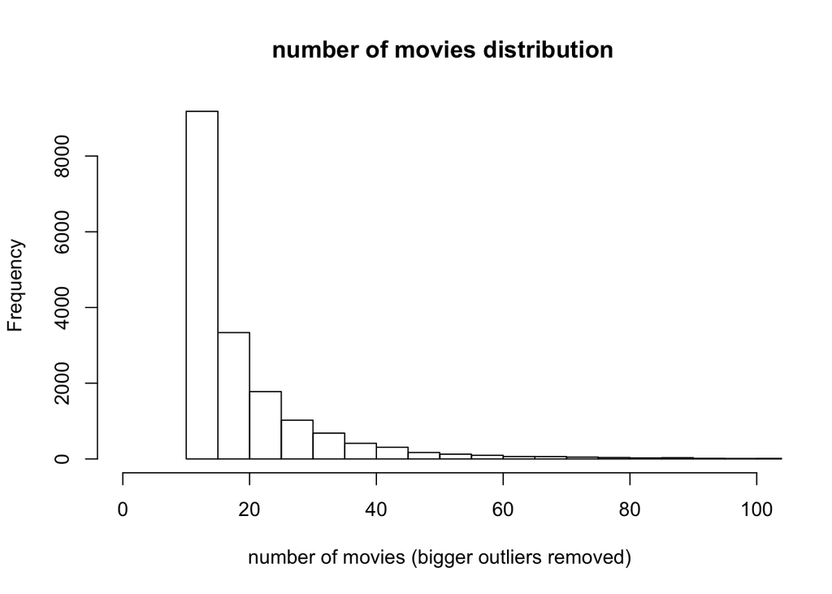

```r
actorskey$ngenres <- str_count(as.matrix(actorskey[,5]), ",")+1;
hist(actorskey$movies_95_04, main = " number of movies distribution", xlim = c(0,100), breaks = 100, xlab = "number of movies (bigger outliers removed)");
```

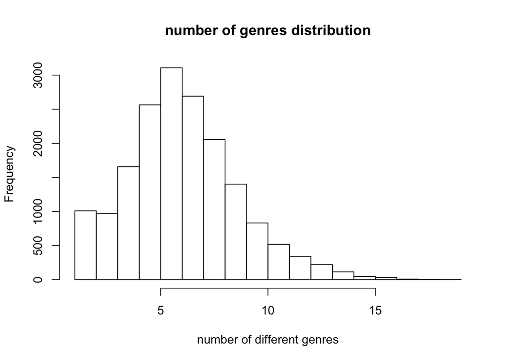

```r
hist(actorskey$ngenres, main = "number of genres distribution", xlab = "number of different genres")
```

```r
xy <- actorskey[order(actorskey$ngenres, decreasing = TRUE),][1:20,]

xy[,c("name","ngenres","movies_95_04")]
```

```
##                          name ngenres movies_95_04
##  1:       Madsen, Michael (I)      19           67
##  2:            Curry, Tim (I)      18           60
##  3:             McKellen, Ian      18           54
##  4:             Ermey, R. Lee      18           39
##  5: Richardson, Kevin Michael      17          120
##  6:              Depp, Johnny      17           58
##  7:              Mallow, Dave      17           58
##  8:         Roberts, Eric (I)      17           72
##  9:         Auberjonois, Rene      17           39
## 10:               Busey, Gary      17           59
## 11:              Soucie, Kath      17          113
## 12:              Perlman, Ron      17           63
## 13:          Carradine, David      17           58
## 14:             Burton, Corey      16          104
## 15:            Thornton, Kirk      16           88
## 16:           Sorich, Michael      16           69
## 17:             Howard, Clint      16           58
## 18:              Strong, Tara      16           91
## 19:              LaMarr, Phil      16           68
## 20:            McGregor, Ewan      16           43
```

Obtain three vectors with the degree, betweeness and closeness for each vertex of the actors’ graph.

```r
class(deg) <- degree(actors_graph, mode="total")
btw <-betweenness(actors_graph)
cls <-closeness(actors_graph)
centrality_table <- cbind(deg, btw, cls) #,ed_btw)
centrality_table <- as.data.frame(centrality_table)
centrality_table <- setDT(centrality_table, keep.rownames = TRUE)[]
centrality_table <- as.data.table(centrality_table)
centrality_table$ngenres <- actorskey$ngenres
centrality_table$n_movies <- actorskey$movies_95_04
centrality_table$main_genre <- actorskey$main_genre
```

Obtain the list of the 20 actors with the largest degree centrality . Show a list with the degree, betweenness, and closeness centralities, the name of the actor, the number of movies, the main genre, and the number of genres in which the actor has participated. *How do you explain the high degree of the top-20 list?* #### Top 20 actors with highest degree

```r
centrality_table[order(centrality_table$deg, decreasing = T),][1:20]
```

```
##                      rn deg        btw          cls ngenres n_movies
##  1:     Davis, Mark (V) 784  184760.34 4.323623e-07      10      540
##  2:   Sanders, Alex (I) 610  324676.39 4.338777e-07      10      467
##  3:    North, Peter (I) 599  255058.99 4.330232e-07       8      460
##  4:         Marcus, Mr. 584 1324799.70 4.359985e-07       6      435
##  5:      Tedeschi, Tony 561  505952.84 4.344437e-07      11      364
##  6:          Dough, Jon 555  935125.90 4.351906e-07       8      300
##  7:     Stone, Lee (II) 545   64769.71 4.320082e-07       7      403
##  8:       Voyeur, Vince 533  335050.49 4.323307e-07      10      370
##  9: Lawrence, Joel (II) 500  149202.75 4.323819e-07       7      315
## 10:   Steele, Lexington 493   87733.75 4.324195e-07       8      429
## 11:         Ashley, Jay 490  131641.20 4.328334e-07       8      309
## 12:           Boy, T.T. 475  146829.97 4.332283e-07       8      336
## 13: Cannon, Chris (III) 471  534138.08 4.353008e-07       9      287
## 14:         Jeremy, Ron 471 8433928.22 4.394646e-07      14      280
```

[output cut: 27 more lines]

Central nodes with high degree are those that have most links with other nodes. It makes sense that Adult industry Actors dominate the top 20, because it is usual for that genre’s actors to have multiple interactions within their network. According to IMBD Alex Sanders has directed more than 100 movies and has been involve as an actor in many more. This could be the reason why he is connected and has many edges.

Obtain the list of the 20 actors with the largest betweenness centrality . Show a list with the degree, betweenness, and closeness centralities, the name of the actor, the number of movies, the main genre, and the number of genres in which the actor has participated. *Is this list similar to the one obtained for degree centrality? Why? How do you explain the high betweenness of the top-20 list?*

```r
centrality_table[order(centrality_table$btw, decreasing = T),][1:20]
```

```
##                           rn deg     btw          cls ngenres n_movies
##  1:              Jeremy, Ron 471 8433928 4.394646e-07      14      280
##  2:         Shahlavi, Darren   8 4302671 4.280921e-07       9       16
##  3:     Del Rosario, Monsour   6 4267096 4.219479e-07       9       20
##  4:         Chan, Jackie (I) 135 4148216 4.394395e-07      12       59
##  5:        Cruz, Pen\xe9lope 182 3730691 4.405149e-07      13       46
##  6:     Depardieu, G\xe9rard 159 3297737 4.390450e-07      11       56
##  7:          Arquette, David 199 2717568 4.401418e-07      16       45
##  8:        Bachchan, Amitabh  66 2512696 4.330960e-07      13       35
##  9:        Soualem, Zinedine 121 2367794 4.361605e-07      12       65
## 10:                Kier, Udo  64 2331680 4.394724e-07      15       69
## 11:          Del Rio, Olivia 168 2300975 4.346224e-07       6       84
## 12:                  Pel\xe9   7 2263239 4.284272e-07       4       10
## 13:                    Ice-T 153 2246827 4.395765e-07      15       63
## 14:           Corbett, Denis  12 2138339 4.331979e-07       8       17
```

[output cut: 27 more lines]

Central actors in betweeness are those that have “control” of other pairs of actors. When we analyze the list we find that many of the actors are not from USA, meaning they are foreign such as Zinedine Soualem, Darren Shahlavi, Penelope cruz. This appears to be a reason why they are bridges between networks, because they connect networks from country to country. For example, Darren Shahlavi the Iranian actor who specializes in martial arts is a good example of a bridge because he specializes in a very particular genre. As for the actor heading the list, he resembles the connection to the previous Degree table, as he has acted in many genres resulting as a bridge between actors who do not normally work together.

Obtain the list of the 20 actors with the largest closeness centrality . Show a list with the degree, betweenness, and closeness centralities, the name of the actor, the number of movies, the main genre, and the number of genres in which the actor has participated. *Is this list similar to the one obtained for degree and betweenness centralities? Why? How do you explain the high closeness of the top-20 list?*

```r
centrality_table[order(centrality_table$cls, decreasing = T),][1:20]
```

```
##                       rn deg       btw          cls ngenres n_movies
##  1:        Diaz, Cameron 361 1318313.8 4.410807e-07      13       59
##  2:     Goldberg, Whoopi 398 1308538.5 4.410499e-07      14      109
##  3:           Hanks, Tom 457 1648365.1 4.409749e-07      13       75
##  4:         Berry, Halle 376 1198497.9 4.409620e-07      14       63
##  5:   Jackson, Samuel L. 427 1958455.9 4.409037e-07      14       97
##  6: Douglas, Michael (I) 263  976438.9 4.408397e-07      11       41
##  7:      De Niro, Robert 257 1087885.2 4.407583e-07      13       51
##  8:    Willis, Bruce (I) 137  887898.8 4.407255e-07      14       52
##  9:       Hopper, Dennis 231  870351.2 4.407032e-07      16      106
## 10:   Washington, Denzel 253  591803.3 4.406898e-07      10       49
## 11:      Hoffman, Dustin 259  521739.6 4.406478e-07      12       56
## 12:       Kidman, Nicole 280  695272.4 4.406459e-07      12       54
## 13:       Travolta, John 335  590559.9 4.405315e-07      13       63
## 14:         Stiller, Ben 382  886911.7 4.405156e-07      14       66
```

[output cut: 27 more lines]

An actor 𝐼 is central in closeness if it can easily interact with all other actors, that is the distance 𝑑(𝑖, 𝑗) to all other actors 𝑗 is short. When we observe the results of all this actors we see a lot of worldwide popular well-known candidates such as Cameron Diaz, Tom Hanks, Samuel L Jackson, Robert De Niro, and many more. This makes sense because these actors appear to be connected to many other actors, even if they don’t have the highest degrees. Their distance to other actors is shorter due to the movies they make that connects them with the right actors that have shorter path to others creating a shorter chain. We can use Whoopie Goldberg as an example of an actress who starred in many movies alongside different actors in w wide array of genres, therefore being among the top actresses. ## Wikipedia

Obtain the list of the 20 Wikipedia pages with the largest out-degree centrality . Show a list with the outdegree, betweenness, and closeness centralities, and degree prestige, the Wikipedia identifier, and the title of the page (label).

```r
deg <- degree(wikigraph, mode="out")
btw <- betweenness(wikigraph, directed=T, weights=NA)
cls <- closeness(wikigraph, mode="total", weights=NA)
cls_out <-closeness(wikigraph, mode="out", weights=NA)
deg_pres <-page.rank(wikigraph, directed=T, weights=NA)
```

```r
wiki_centrality_table <- cbind(deg, btw, cls, cls_out)
wiki_centrality_table <- as.data.frame(wiki_centrality_table)
wiki_centrality_table<- setDT(wiki_centrality_table, keep.rownames = TRUE)[]
wiki_centrality_table<- as.data.table(wiki_centrality_table)
wiki_centrality_table$id <- get.vertex.attribute(wikigraph,name =  "id")
wiki_centrality_table$label <- get.vertex.attribute(wikigraph,name =  "label")
```

#### top 20 highest degree

```r
wiki_centrality_table[order(wiki_centrality_table$deg, decreasing = T),][1:20]
```

```
##        rn deg     btw          cls      cls_out    id
##  1:  8437 565       0 1.582014e-08 2.284499e-09  8436
##  2: 19893 556       0 1.582009e-08 2.279639e-09 19892
##  3: 12753 426       0 1.581982e-08 2.275359e-09 12752
##  4:  8550 335       0 1.581835e-08 2.247659e-09  8549
##  5: 19076 320       0 1.581864e-08 2.266274e-09 19075
##  6: 11290 299       0 1.581782e-08 2.264856e-09 11289
##  7: 26152 297       0 1.581831e-08 2.284194e-09 26151
##  8:  7706 287       0 1.581800e-08 2.262748e-09  7705
##  9:  4248 275       0 1.581759e-08 2.261202e-09  4247
## 10:   957 262       0 1.581808e-08 2.267962e-09   956
## 11: 25974 261       0 1.581772e-08 2.261619e-09 25973
## 12: 10318 256 4460539 1.581868e-08 2.238781e-09 10317
## 13: 12111 249       0 1.581723e-08 2.261055e-09 12110
## 14: 10186 209       0 1.581814e-08 2.254334e-09 10185
```

[output cut: 27 more lines]

*How do you explain the high degree of the top-20 list?* Central nodes with high degrees are those that have most links with other nodes. A very curios trend observed is that almost all links within the top 20 highest degrees are mathematics articles, or subjects related to maths. This is observed due to the amount of hyperlinks referring to mathematical concepts in wikipedia pages throughout the network, along with many citations.

Obtain the list of the 20 Wikipedia pages with the largest betweenness centrality . Show a list with the outdegree, betweenness, and closeness centralities, and degree prestige, the Wikipedia identifier, and the title of the page (label).

#### top 20 betweenness

```r
wiki_centrality_table[order(wiki_centrality_table$btw, decreasing = T),][1:20]
```

```
##        rn deg      btw          cls      cls_out    id
##  1: 12534  29 21664351 1.582031e-08 2.238771e-09 12533
##  2: 10808  44 18212635 1.582069e-08 2.238775e-09 10807
##  3: 22929   6 17171567 1.581961e-08 2.238723e-09 22928
##  4: 13664  54 14120503 1.582007e-08 2.238783e-09 13663
##  5: 26408  23 12558644 1.582016e-08 2.238767e-09 26407
##  6: 23130  27 12549458 1.582173e-08 2.238772e-09 23129
##  7: 24317   8 10439577 1.582066e-08 2.238741e-09 24316
##  8: 21613  12 10020865 1.581733e-08 2.238738e-09 21612
##  9:   437   7  9106791 1.581954e-08 2.238690e-09   436
## 10: 10167  21  8404528 1.581884e-08 2.238760e-09 10166
## 11: 19840  60  8315357 1.581890e-08 2.238780e-09 19839
## 12: 20312  48  7892473 1.581920e-08 2.238754e-09 20311
## 13:  6106  16  7685991 1.581804e-08 2.238772e-09  6105
## 14:  4111  16  7468319 1.581852e-08 2.238754e-09  4110
```

[output cut: 27 more lines]

*How do you explain the high betweenness of the top-20 list?* Highest nodes in betweeness are those that act as bridges to other Wikipedia nodes. A pattern observed with all Wikipedia articles found within this 20 top list are from different subjects, which means that they are likely to be links that connect one subject with an other. For example, links 12533 of calculus could be the bridge to a link to the history network.

Obtain the list of the 20 Wikipedia pages with the largest closeness centrality . Show a list with the outdegree, betweenness, and closeness centralities, and degree prestige, the Wikipedia identifier, and the title of the page (label).

#### top 20 closeness

```r
wiki_centrality_table[order(wiki_centrality_table$cls, decreasing = T),][1:20]
```

```
##        rn deg         btw          cls      cls_out    id
##  1: 23130  27 12549458.18 1.582173e-08 2.238772e-09 23129
##  2: 22473  61  5587745.22 1.582087e-08 2.238805e-09 22472
##  3: 10808  44 18212634.97 1.582069e-08 2.238775e-09 10807
##  4: 24317   8 10439577.02 1.582066e-08 2.238741e-09 24316
##  5: 11817  13  7276429.06 1.582054e-08 2.238738e-09 11816
##  6: 12534  29 21664351.12 1.582031e-08 2.238771e-09 12533
##  7: 26408  23 12558644.11 1.582016e-08 2.238767e-09 26407
##  8:  8437 565        0.00 1.582014e-08 2.284499e-09  8436
##  9: 19893 556        0.00 1.582009e-08 2.279639e-09 19892
## 10: 13664  54 14120503.37 1.582007e-08 2.238783e-09 13663
## 11:  3195   9  1720506.44 1.581998e-08 2.238698e-09  3194
## 12: 14368  10  6237461.94 1.581996e-08 2.238618e-09 14367
## 13: 23696   9  7275027.15 1.581991e-08 2.238743e-09 23695
## 14:  5987  36  2105313.59 1.581985e-08 2.238791e-09  5986
```

[output cut: 27 more lines]

*How do you explain the high closeness of the top-20 list?* An actor 𝐼 is central in closeness if it can easily interact with all other actors, that is the distance 𝑑(𝑖, 𝑗) to all other actors, where 𝑗 is short. A pattern observed is that some of the links with high betweenness and high degree centrality also happen to have closeness centrality. For example, id 12533 is both, central in closeness and betweenness, and id 8436 is also central in high degree and in closeness. This could suggest that the networks are extremely separated from each other, so the nearest path to connect nodes are through betweenness centrality or largest degree centrality.

# Network Models (Optional)

Explore the Erdos-Renyi model and compare its structural properties to those of real-world networks (Wikipedia and actors):

```r
length(E(actors_graph))
```

```
## [1] 287074
```

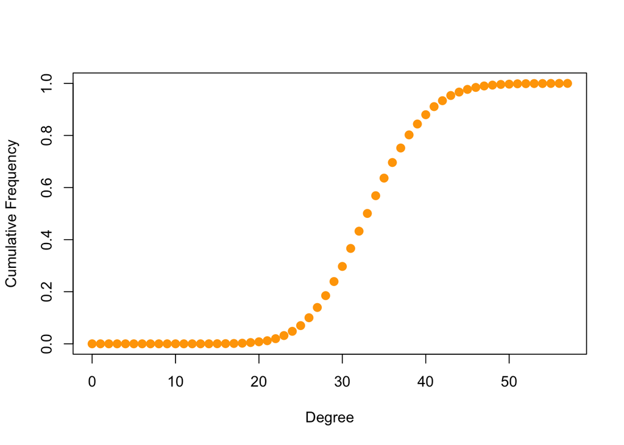

```r
actor_erg <- erdos.renyi.game(length(V(actors_graph)), length(E(actors_graph)), type = "gnm", directed = FALSE)
degdis_erg <- degree_distribution(actor_erg, cumulative = T, mode='all')
erdos_renyi_actor_deg <- degree(actor_erg)
plot( x=0:max(erdos_renyi_actor_deg ), y=1-degdis_erg , pch=19, cex=1.2, col="orange",

      xlab="Degree", ylab="Cumulative Frequency")
```

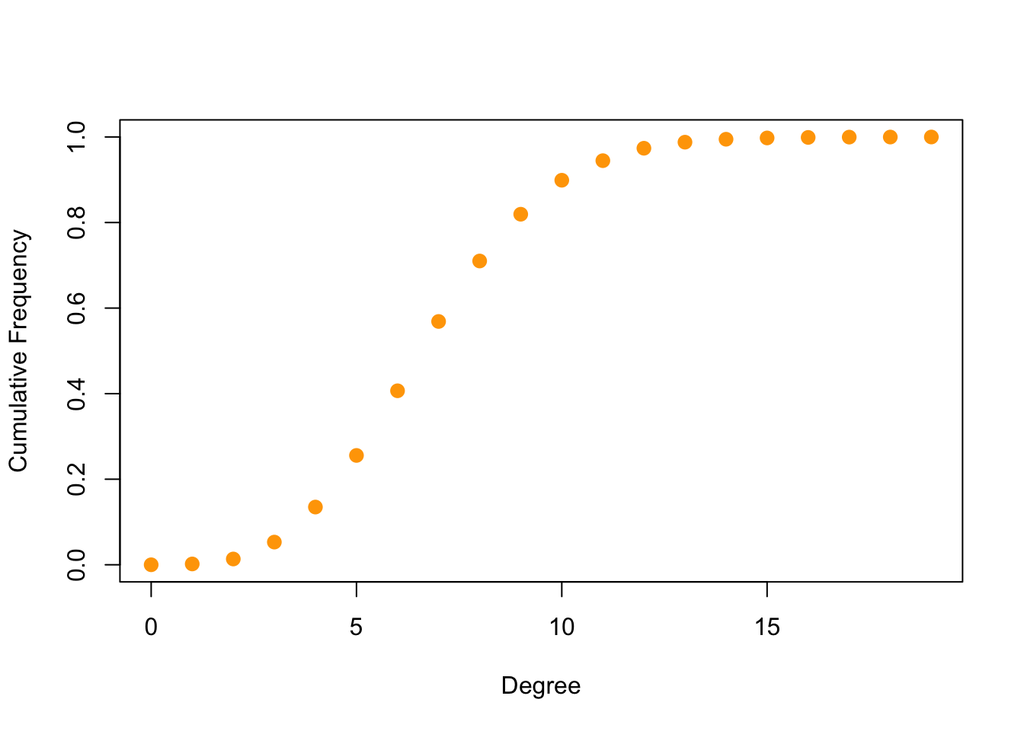

```r
wiki_erg <- erdos.renyi.game(length(V(wikigraph)), length(E(wikigraph)), type = "gnm", directed = TRUE)
degdis_erg <- degree_distribution(wiki_erg, cumulative = T, mode='all')
erdos_renyi_wiki_deg <- degree(wiki_erg)
plot( x=0:max(erdos_renyi_wiki_deg ), y=1-degdis_erg , pch=19, cex=1.2, col="orange",

      xlab="Degree", ylab="Cumulative Frequency")
```

* Degree distribution P(k) * Network Diameter and Average Path Length * (Global and Local) Clustering Coefficient

# Comunity detection (Optional)

Use any community detection algorithm in the Wikipedia network and/or in the actors’ network and discuss whether the communities found make sense according to the vertex labels.

```r
fastgreedy.community(actors_graph)
```

```
## IGRAPH clustering fast greedy, groups: 55, mod: 0.83
## + groups:
##   $`1`
##      [1] "Bellows, Gil"
##      [2] "Macfadyen, Angus"
##      [3] "Djola, Badja"
##      [4] "Twiggy"
##      [5] "Winfrey, Oprah"
##      [6] "Welch, Raquel"
##      [7] "Scarborough, Adrian"
##      [8] "Weinberg, Max (I)"
##      [9] "Hingle, Pat"
##   + ... omitted several groups/vertices
```

fastgrredy uses a buttom-up hierarchical approach. It optimizes for modularity in a greedy manner. The modularity of a graph with respect to some division (or vertex types) measures how good the division is, or how separated are the different vertex types from each other. Initially, every vertex belongs to a separate community, and communities are merged iteratively such that each merge is locally optimal (i.e. yields the largest increase in the current value of modularity).

# Final project proposal

Write a short proposal for your final project.

we found 2 datasets that were of our interest.

first one, Open flights datset, has the following description “The data is downloaded from Openflights.org. Unlike the BTS data, this dataset contains ties between two non-US-based airports. As such, it gives much more of a complete picture and avoids the sample selection. The weights in this network refer to the number of routes between two airports.” 2.9k nodes,30.5k edges. http://networkrepository.com/inf-openflights.php

an Amazon recommendation networks, Description: Network was collected by crawling Amazon website. It is based on Customers Who Bought This Item Also Bought feature of the Amazon website. If a product A is frequently co-purchased with product B and vice-versa (i.e., product B is co-purchased with product A), then graph contains an edge between A and B. 91.8k nodes and 125.7k edges. http://networkrepository.com/rec-amazon.php